# UK Graduate Outcomes Data Exploration

# Introduction

The aim of this document is to use recent graduate employment outcome data to learn more about differences in the types of job and conditions of employment people who graduate with different types of degree enter after graduation

## Data and resource used

The UK government publishes an official statistics page (13 June 2017) ‘Graduate outcomes for all subjects by university’. It’s available [here](https://www.gov.uk/government/statistics/graduate-outcomes-for-all-subjects-by-university)

I’m going to download and place three files in the directory `data/`

- [Main Tables: SFR18/2017](https://www.gov.uk/government/uploads/system/uploads/attachment_data/file/619433/SFR18_2017_Institution_subject_table.xlsx)
- [Underlying Data: SFR18/2017](https://www.gov.uk/government/uploads/system/uploads/attachment_data/file/619435/SFR18_2017_Institution_subject_data.csv)
- [Metadata: SFR18/2017](https://www.gov.uk/government/uploads/system/uploads/attachment_data/file/618557/SFR18_2017_metadata.txt)

```r
dir.create("data")
```

```
'data' already exists
```

```r
# Main table in excel
download.file(
  "https://www.gov.uk/government/uploads/system/uploads/attachment_data/file/619433/SFR18_2017_Institution_subject_table.xlsx",
  "data/subject_excel.xlsx"
  )
# Underlying data as csv
download.file(
  "https://www.gov.uk/government/uploads/system/uploads/attachment_data/file/619435/SFR18_2017_Institution_subject_data.csv",
  "data/underlying_data.csv"
  )
# metadata as txt
download.file(
  "https://www.gov.uk/government/uploads/system/uploads/attachment_data/file/618557/SFR18_2017_metadata.txt",
  "data/metadata.txt"
  )
```

In this case it was more straightforward to download the files manually, as the versions created using download.file were slightly different and corrupted in the case of the Excel file. First lesson!

We’re going to look mainly at the contents of the file `SFR18_2017_Institution_subject_data.csv`.

```r
#install.packages("pacman")
pacman::p_load("tidyverse")
```

```r
dta <- read_csv("data/SFR18_2017_Institution_subject_data.csv")
```

Now let’s think about data tidying

```r
dta %>%
  mutate(
    UKPRN = as.character(UKPRN)
  ) %>%
  mutate_at(vars(yearsAfterGraduation:prAttIncluded), funs(as.numeric)) %>%
  filter(!is.na(grads), !is.na(matched)) %>%
  filter(grads > 0, matched > 0) -> dta2
```

[output not shown]

Now let’s try to estimate the proportion in employment after 1 to 5 years

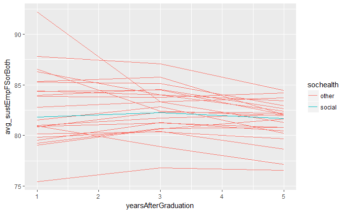

```r
dta2 %>%
  select(subject, yearsAfterGraduation, matched, sustEmpFSorBoth) %>%
  filter(!is.na(sustEmpFSorBoth)) %>%
  mutate(tmp = matched * sustEmpFSorBoth) %>%
  group_by(yearsAfterGraduation, subject) %>%
  summarise(avg_sustEmpFSorBoth = sum(tmp) / sum(matched)) %>%
  ungroup() %>%
  mutate(sochealth = case_when(
    subject == "Social studies (excluding economics)" ~ "social",
    TRUE ~ "other"
  ) ) %>%
  ggplot(aes(x = yearsAfterGraduation, y = avg_sustEmpFSorBoth, group = subject, colour = sochealth))+
  geom_line()
```

Now let’s try the same, but with employment only

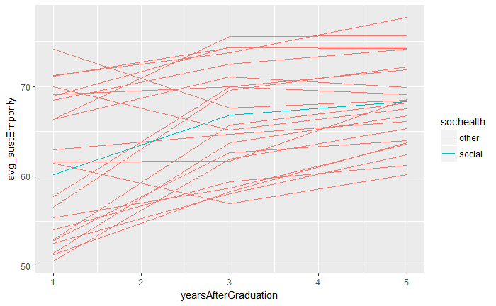

```r
dta2 %>%
  select(subject, yearsAfterGraduation, matched, sustEmpOnly) %>%
  filter(!is.na(sustEmpOnly)) %>%
  mutate(tmp = matched * sustEmpOnly) %>%
  group_by(yearsAfterGraduation, subject) %>%
  summarise(avg_sustEmponly = sum(tmp) / sum(matched)) %>%
  ungroup() %>%
  mutate(sochealth = case_when(
    subject == "Social studies (excluding economics)" ~ "social",
    TRUE ~ "other"
  ) ) %>%
  ggplot(aes(x = yearsAfterGraduation, y = avg_sustEmponly, group = subject, colour = sochealth))+
  geom_line()
```

Now median salary

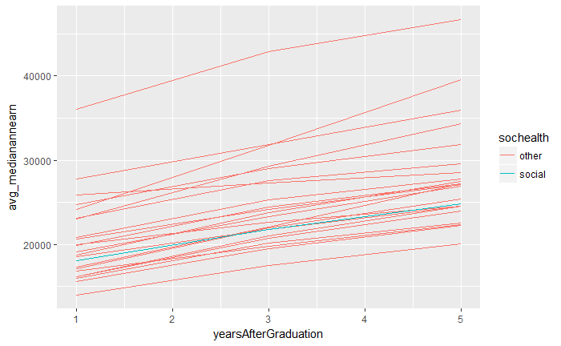

```r
dta2 %>%
  select(subject, yearsAfterGraduation, matched, medianAnnEarn) %>%
  filter(!is.na(medianAnnEarn)) %>%
  mutate(tmp = matched * medianAnnEarn) %>%
  group_by(yearsAfterGraduation, subject) %>%
  summarise(avg_medianannearn = sum(tmp) / sum(matched)) %>%
  ungroup() %>%
  mutate(sochealth = case_when(
    subject == "Social studies (excluding economics)" ~ "social",
    TRUE ~ "other"
  ) ) %>%
  ggplot(aes(x = yearsAfterGraduation, y = avg_medianannearn, group = subject, colour = sochealth))+
  geom_line()
```

Five years after graduation

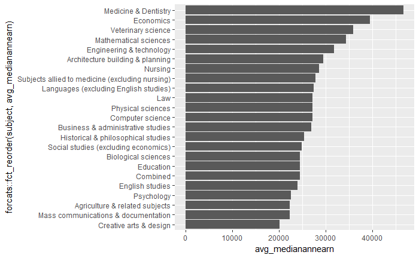

```r
dta2 %>%
  select(subject, yearsAfterGraduation, matched, medianAnnEarn) %>%
  filter(yearsAfterGraduation == 5) %>%
  filter(!is.na(medianAnnEarn)) %>%
  mutate(tmp = matched * medianAnnEarn) %>%
  group_by(yearsAfterGraduation, subject) %>%
  summarise(avg_medianannearn = sum(tmp) / sum(matched)) %>%
  ungroup() %>%
  ggplot(aes(x = forcats::fct_reorder(subject,avg_medianannearn), y = avg_medianannearn))+
  geom_bar(stat = "identity") +
  coord_flip()
```

Now to break down by gender

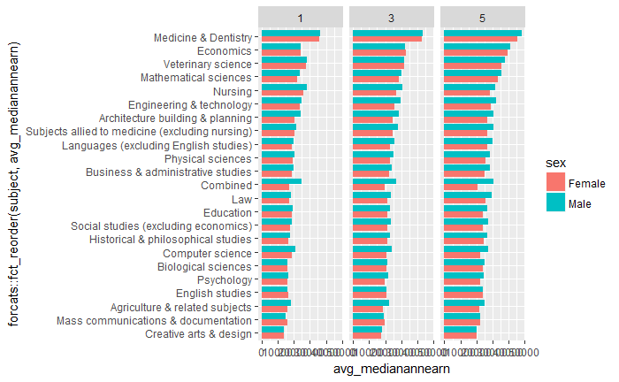

```r
dta2 %>%
  select(subject, sex, yearsAfterGraduation, matched, medianAnnEarn) %>%
  filter(!is.na(medianAnnEarn)) %>%
  filter(sex != "Female + Male") %>%
  mutate(tmp = matched * medianAnnEarn) %>%
  group_by(yearsAfterGraduation, subject, sex) %>%
  summarise(avg_medianannearn = sum(tmp) / sum(matched)) %>%
  ungroup() %>%
  ggplot(aes(x = forcats::fct_reorder(subject,avg_medianannearn), group = sex, fill = sex, y = avg_medianannearn))+
  geom_bar(stat = "identity", position = "dodge") +
  coord_flip() +
  facet_wrap(~ yearsAfterGraduation)
```

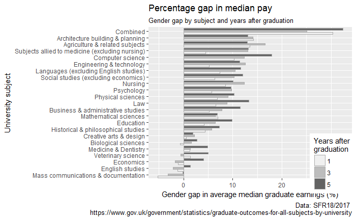

```r
dta2 %>%
  select(subject, sex, yearsAfterGraduation, matched, medianAnnEarn) %>%
  filter(!is.na(medianAnnEarn)) %>%
  filter(sex != "Female + Male") %>%
  mutate(tmp = matched * medianAnnEarn) %>%
  group_by(yearsAfterGraduation, subject, sex) %>%
  summarise(avg_medianannearn = sum(tmp) / sum(matched)) %>%
  ungroup() %>%
  spread(sex, avg_medianannearn) %>%
  mutate(sex_gap = 100 * (Male - Female) / Male) %>%
  ggplot(aes(x = forcats::fct_reorder(subject,sex_gap), group = factor(yearsAfterGraduation), fill = factor(yearsAfterGraduation), y = sex_gap))+
  geom_bar(stat = "identity", position = "dodge", colour = "darkgrey") +
  coord_flip() +
  labs(
    y = "Gender gap in average median graduate earnings (%)",
    x = "University subject",
    fill = "Years after\ngraduation",
    title = "Percentage gap in median pay",
    subtitle = "Gender gap by subject and years after graduation",
    caption = "Data: SFR18/2017 \nhttps://www.gov.uk/government/statistics/graduate-outcomes-for-all-subjects-by-university"
  )  +
  scale_fill_brewer(palette = "Greys", direction = 1) +
  theme_grey() +
  theme(legend.position = c(0.9, 0.1))
ggsave("figures/gender_gap.png", width = 20, height = 20, units = "cm", dpi = 300)
```

Let’s try to get some summary stats

```r
dta2 %>%
  select(subject, sex, yearsAfterGraduation, matched, medianAnnEarn) %>%
  filter(!is.na(medianAnnEarn)) %>%
  filter(sex != "Female + Male") %>%
  mutate(tmp = matched * medianAnnEarn) %>%
  group_by(yearsAfterGraduation, sex) %>%
  summarise(avg_medianannearn = sum(tmp) / sum(matched)) %>%
  ungroup() %>%
  spread(sex, avg_medianannearn) %T>% (
    function(..){
      .. %>%
        mutate(female_growth = Female / Female[yearsAfterGraduation == 1]) %>%
        mutate(male_growth = Male / Male[yearsAfterGraduation == 1]) %>%
        print()
    }
  ) %>%
  mutate(sex_gap = 100 * (Male - Female) / Male)
```

| yearsAfterGraduation | Female | Male | female_growth | male_growth |
| --- | --- | --- | --- | --- |
| 1 | 18607.96 | 19983.12 | 1.000000 | 1.000000 |
| 3 | 22352.76 | 24797.52 | 1.201247 | 1.240923 |
| 5 | 25150.62 | 28431.52 | 1.351605 | 1.422777 |

| yearsAfterGraduation | Female | Male | sex_gap |
| --- | --- | --- | --- |
| 1 | 18607.96 | 19983.12 | 6.881596 |
| 3 | 22352.76 | 24797.52 | 9.858879 |
| 5 | 25150.62 | 28431.52 | 11.539665 |

Want to know the average gender gap in number of graduates by provide and subject

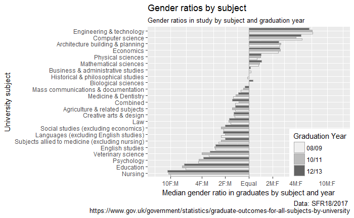

```r
subject_gender_balance <- dta2 %>%
      group_by(yearsAfterGraduation, providerName, subject) %>%
      select(yearsAfterGraduation, providerName, subject, sex, grads) %>%
      filter(sex != "Female + Male") %>%
      spread(sex, grads) %>%
      mutate(gender_balance = Male / Female) %>%
      group_by(yearsAfterGraduation, subject) %>%
      summarise(median_gender_balance = median(gender_balance)) %>%
      ungroup()
subject_gender_balance %>%
  mutate(graduation_year = case_when(
    yearsAfterGraduation == 1 ~ "12/13",
    yearsAfterGraduation == 3 ~ "10/11",
    yearsAfterGraduation == 5 ~ "08/09"
  )) %>%
  ggplot(
  aes(x = forcats::fct_reorder(subject,median_gender_balance), y = median_gender_balance,
  fill=factor(graduation_year), group = factor(graduation_year))
  ) +
  geom_bar(stat = "identity", position = "dodge", colour = "darkgrey") +
  coord_flip() +
  scale_y_log10(
    breaks = c(0.05, 0.10, 0.25, 0.50, 1, 2, 4, 10, 20),
    labels = c("20F:M", "10F:M", "4F:M", "2F:M", "Equal", "2M:F", "4M:F", "10M:F", "20M:F"),
    limits = c(1/15, 15)
  ) +
  scale_fill_brewer(palette = "Greys", direction = 1) +
  theme_grey() +
    labs(
    y = "Median gender ratio in graduates by subject and year",
    x = "University subject",
    fill = "Graduation Year",
    title = "Gender ratios by subject",
    subtitle = "Gender ratios in study by subject and graduation year",
    caption = "Data: SFR18/2017 \nhttps://www.gov.uk/government/statistics/graduate-outcomes-for-all-subjects-by-university"
  )  +
  theme(legend.position = c(0.85, 0.15))
ggsave("figures/gender_gap_subject.png", width = 20, height = 20, units = "cm", dpi = 300)
```

We might be interested in seeing whether subjects with high male:female ratios at time of study then have higher disparaties in median earnings in the years after graduation. A possible hypothesis would be as follows: being greatly outnumbered when studying a degree sends a signal that the subject isn’t really ‘for the likes of you’. Faced with the expectation, set during study, of being highly outnumbered means you’re more likely to move to a more balanced type of occupation after a few years. To the extent that your earning potential will be higher for subjects you’re qualified in - i.e. your degree subject - this will mean more of the predominant gender will stay in their degree subject, and more of the minority gender will leave. A positive association between the gender bias at time of study and subsequent earnings will therefore be expected if this hypothesis is correct.

Let’s do this now for 1, 3 and 5 years after graduation:

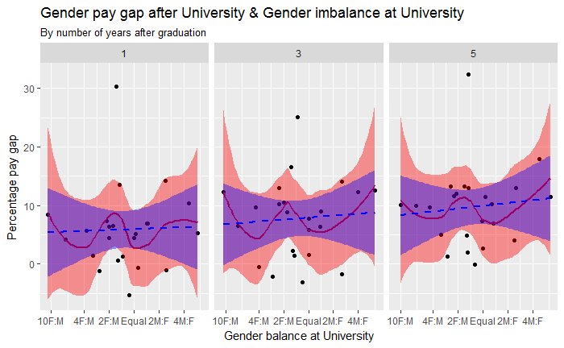

```r
dta2 %>%
  select(subject, sex, yearsAfterGraduation, matched, medianAnnEarn) %>%
  filter(!is.na(medianAnnEarn)) %>%
  filter(sex != "Female + Male") %>%
  mutate(tmp = matched * medianAnnEarn) %>%
  group_by(yearsAfterGraduation, subject, sex) %>%
  summarise(avg_medianannearn = sum(tmp) / sum(matched)) %>%
  ungroup() %>%
  spread(sex, avg_medianannearn) %>%
  mutate(sex_gap = 100 * (Male - Female) / Male) %>%
  inner_join(
    subject_gender_balance
  ) %>%
  select(yearsAfterGraduation, subject, median_gender_balance, sex_gap) %>%
  ggplot(aes(x = median_gender_balance, y = sex_gap)) +
  scale_x_log10(
    breaks = c(0.05, 0.10, 0.25, 0.50, 1, 2, 4, 10, 20),
    labels = c("20F:M", "10F:M", "4F:M", "2F:M", "Equal", "2M:F", "4M:F", "10M:F", "20M:F")
                ) +
  geom_point() +
  facet_wrap(~yearsAfterGraduation) +
  geom_smooth(col = "red", fill = "red") +
  geom_smooth(method = "lm", col = "blue", linetype = "dashed", fill = "blue") +
  labs(x = "Gender balance at University", y = "Percentage pay gap", title = "Gender pay gap after University & Gender imbalance at University", subtitle = "By number of years after graduation")
```

```r
NA
```

Let’s show this for the fifth year with labelling

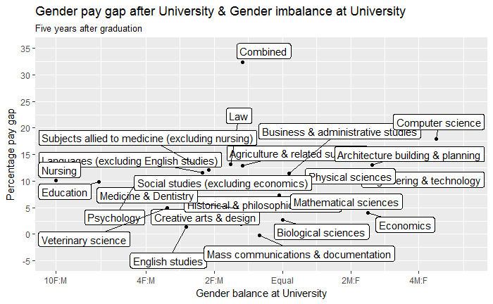

```r
dta2 %>%
  select(subject, sex, yearsAfterGraduation, matched, medianAnnEarn) %>%
  filter(!is.na(medianAnnEarn)) %>%
  filter(sex != "Female + Male") %>%
  mutate(tmp = matched * medianAnnEarn) %>%
  group_by(yearsAfterGraduation, subject, sex) %>%
  summarise(avg_medianannearn = sum(tmp) / sum(matched)) %>%
  ungroup() %>%
  spread(sex, avg_medianannearn) %>%
  mutate(sex_gap = 100 * (Male - Female) / Male) %>%
  inner_join(
    subject_gender_balance
  ) %>%
  select(yearsAfterGraduation, subject, median_gender_balance, sex_gap) %>%
  filter(yearsAfterGraduation == 5) %>%
  ggplot(aes(x = median_gender_balance, y = sex_gap)) +
  scale_x_log10(
    breaks = c(0.05, 0.10, 0.25, 0.50, 1, 2, 4, 10, 20),
    labels = c("20F:M", "10F:M", "4F:M", "2F:M", "Equal", "2M:F", "4M:F", "10M:F", "20M:F")
                ) +
  scale_y_continuous(
    limits = c(-5, 35),
    breaks = seq(-5, 35, by = 5)
  ) +
  geom_point() +
  ggrepel::geom_label_repel(aes(label = subject)) +
  labs(x = "Gender balance at University", y = "Percentage pay gap", title = "Gender pay gap after University & Gender imbalance at University", subtitle = "Five years after graduation")
ggsave("figures/labelled_reln.png", width = 25, height = 25, units = "cm", dpi = 300)
```